# hw-lego-Alice-Tang

```r
view(lego_sales)
```

Exercise 1: What are the three most common first names of purchasers?

```r
lego_sales_1 <- lego_sales %>% count(first_name) %>% arrange(desc(n)) %>% head(3)
lego_sales_1
```

| first_name | n |
| --- | --- |
| Jackson | 13 |
| Jacob | 11 |
| Joseph | 11 |

Answer: In this sample, the first three common names of purchasers are Jackson, Jacob, and Joseph.

Exercise 2: What are the three most common themes of Lego sets purchased?

```r
lego_sales_2 <- lego_sales %>% count(theme) %>% arrange(desc(n)) %>% head(3)
lego_sales_2
```

| theme | n |
| --- | --- |
| Star Wars | 75 |
| Nexo Knights | 64 |
| Gear | 55 |

Answer: In this sample, the three most common themes of of Lego sets purchased are Star Wars, Nexo Knights, and Gear

Exercise 3: Among the most common theme of Lego sets purchased, what is the most common subtheme?

```r
lego_sales_3 <- lego_sales %>% filter(theme == "Star Wars" | theme == "Nexo Knights" | theme == "Gear", !is.na(subtheme)) %>% count(subtheme) %>% arrange(desc(n)) %>% head(1)
lego_sales_3
```

| subtheme | n |
| --- | --- |
| Ultimate | 22 |

Answer: In this sample, among the most common theme of Lego sets purchased, the most common subtheme is Ultimate.

Exercise 4: Create a new variable called age_group and group the ages into the following categories: “18 and under”, “19 - 25”, “26 - 35”, “36 - 50”, “51 and over”.

```r
lego_sales_with_age_group <- mutate(lego_sales, age_group = case_when(age <= 18 ~ "18 and under", age <= 25  ~ "19 - 25", age <= 35  ~ "26 - 35", age <= 50  ~ "36 - 50", age <= Inf  ~ "51 and over"))
lego_sales_with_age_group
```

| first_name | last_name | age | phone_number | set_id | number | theme | subtheme | year | name | pieces | us_price | image_url | quantity | age_group |
| --- | --- | --- | --- | --- | --- | --- | --- | --- | --- | --- | --- | --- | --- | --- |
| Kimberly | Beckstead | 24 | 216-555-2549 | 24701 | 76062 | DC Comics Super Heroes | Mighty Micros | 2018 | Robin vs. Bane | 77 | 9.99 | http://images.brickset.com/sets/images/76062-1.jpg | 1 | 19 - 25 |
| Neel | Garvin | 35 | 819-555-3189 | 25626 | 70595 | Ninjago | Rise of the Villains | 2018 | Ultra Stealth Raider | 1093 | 119.99 | http://images.brickset.com/sets/images/70595-1.jpg | 1 | 26 - 35 |
| Neel | Garvin | 35 | 819-555-3189 | 24665 | 21031 | Architecture | NA | 2018 | Burj Khalifa | 333 | 39.99 | http://images.brickset.com/sets/images/21031-1.jpg | 1 | 26 - 35 |
| Chelsea | Bouchard | 41 | NA | 24695 | 31048 | Creator | NA | 2018 | Lakeside Lodge | 368 | 29.99 | http://images.brickset.com/sets/images/31048-1.jpg | 1 | 36 - 50 |
| Chelsea | Bouchard | 41 | NA | 25626 | 70595 | Ninjago | Rise of the Villains | 2018 | Ultra Stealth Raider | 1093 | 119.99 | http://images.brickset.com/sets/images/70595-1.jpg | 1 | 36 - 50 |
| Chelsea | Bouchard | 41 | NA | 24721 | 10831 | Duplo | NA | 2018 | My First Caterpillar | 19 | 9.99 | http://images.brickset.com/sets/images/10831-1.jpg | 1 | 36 - 50 |
| Bryanna | Welsh | 19 | NA | 24797 | 75138 | Star Wars | Episode V | 2018 | Hoth Attack | 233 | 24.99 | http://images.brickset.com/sets/images/75138-1.jpg | 1 | 19 - 25 |
| Bryanna | Welsh | 19 | NA | 24701 | 76062 | DC Comics Super Heroes | Mighty Micros | 2018 | Robin vs. Bane | 77 | 9.99 | http://images.brickset.com/sets/images/76062-1.jpg | 3 | 19 - 25 |
| Caleb | Garcia-Wideman | 37 | 907-555-9236 | 24730 | 41115 | Friends | NA | 2018 | Emma's Creative Workshop | 108 | 9.99 | http://images.brickset.com/sets/images/41115-1.jpg | 1 | 36 - 50 |
| Caleb | Garcia-Wideman | 37 | 907-555-9236 | 25611 | 21127 | Minecraft | Minifig-scale | 2018 | The Fortress | NA | 109.99 | http://images.brickset.com/sets/images/21127-1.jpg | 2 | 36 - 50 |

[output cut: 610 more lines]

Exercise 5: Which age group has purchased the highest number of Lego sets.

```r
lego_sales_5 <- count(lego_sales_with_age_group, age_group) %>% arrange(desc(n)) %>% head(1)
lego_sales_5
```

| age_group | n |
| --- | --- |
| 36 - 50 | 216 |

Answer: In this sample, the age group that has purchased the highest number of Lego sets is 36-50

Exercise 6: Which age group has spent the most money on Legos?

```r
lego_sales_6 <- summarise(group_by(lego_sales_with_age_group, age_group), average_paid = mean(us_price)) %>% arrange(desc(average_paid)) %>% head(1)
lego_sales_6
```

| age_group | average_paid |
| --- | --- |
| 36 - 50 | 30.74926 |

Answer: In this sample, the age group that has spent the most money on Legos on average are 36-50.

Exercise 7: Which Lego theme has made the most money for Lego?

```r
lego_sales_7 <- summarise(group_by(lego_sales, theme), sum_made = sum(us_price)) %>% arrange(desc(sum_made)) %>% head(1)
lego_sales_7
```

| theme | sum_made |
| --- | --- |
| Star Wars | 2842.25 |

Answer: In this sample, the Lego theme has made the most money for Lego was Star Wars

Exercise 8: Which area code has spent the most money on Legos? In the US the area code is the first 3 digits of a phone number.

```r
lego_sales_8 <- filter(lego_sales, !is.na(phone_number)) %>% mutate(area_code = str_sub(phone_number, 1, 3)) %>% group_by(area_code) %>% summarise(average_made = mean(us_price)) %>% arrange(desc(average_made)) %>% head(1)
lego_sales_8
```

| area_code | average_made |
| --- | --- |
| 956 | 179.99 |

Exercise 8: Does the number of pieces reflect the price tag. Does it mean that with more pieces the price increases, the less pieces the cheaper the price is. Then, create a data visualization that answers the question, and explain how your visualization answers the question.

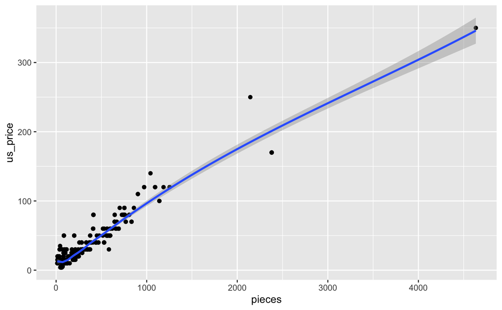

```r
ggplot(lego_sales, mapping = aes(x = pieces, y = us_price)) + geom_point() + geom_smooth()
```

Answer: In this sample, from this graphic visualization, it shows that the price ultimately grows with the increasing amount of pieces in the Lego set, and not the other way around. Thus, the number of pieces reflects the price tag in a positive coloration.